# Loading and pre-processing the data

### Loading and pre-processing the data

- Downloading data

```r
fileurl <- "https://d396qusza40orc.cloudfront.net/repdata%2Fdata%2Factivity.zip"
download.file(fileurl, "PA1.zip", method = "curl")
unzip("PA1.zip")
list.files()
```

- Reading data

```r
act <- read.csv("activity.csv", header = TRUE)
head(act)
```

```
##   steps       date interval
## 1    NA 2012-10-01        0
## 2    NA 2012-10-01        5
## 3    NA 2012-10-01       10
## 4    NA 2012-10-01       15
## 5    NA 2012-10-01       20
## 6    NA 2012-10-01       25
```

### 1) What is mean total number of steps taken per day?

Calculate the total number of steps taken per day

```r
stepdf <- aggregate(act$steps, list(date=act$date), sum, na.rm=TRUE)
names(stepdf) <- c("date", "steps")
stepdf
```

```
##          date steps
## 1  2012-10-01     0
## 2  2012-10-02   126
## 3  2012-10-03 11352
## 4  2012-10-04 12116
## 5  2012-10-05 13294
## 6  2012-10-06 15420
## 7  2012-10-07 11015
## 8  2012-10-08     0
## 9  2012-10-09 12811
## 10 2012-10-10  9900
## 11 2012-10-11 10304
## 12 2012-10-12 17382
## 13 2012-10-13 12426
## 14 2012-10-14 15098
```

[output cut: 47 more lines]

If you do not understand the difference between a histogram and a barplot, research the difference between them. Make a histogram of the total number of steps taken each day

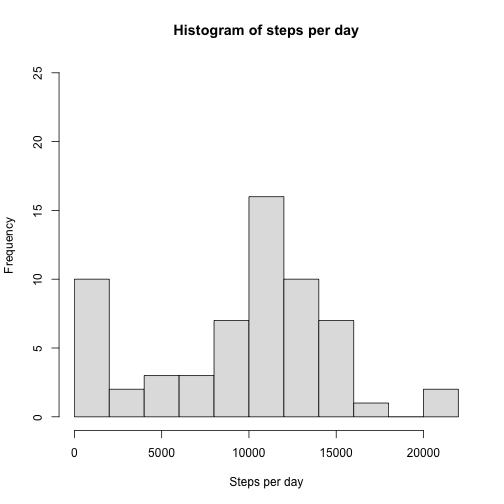

```r
hist(stepdf$steps, 10, main = "Histogram of steps per day", ylim = c(0,25), xlab = "Steps per day", col = "#E0E0E0")
```

Calculate and report the mean and median of the total number of steps taken per day

- Mean

```r
amean <- aggregate(act$steps, list(date=act$date), mean, na.rm=TRUE)
names(amean) <- c("date", "mean")
amean
```

```
##          date       mean
## 1  2012-10-01        NaN
## 2  2012-10-02  0.4375000
## 3  2012-10-03 39.4166667
## 4  2012-10-04 42.0694444
## 5  2012-10-05 46.1597222
## 6  2012-10-06 53.5416667
## 7  2012-10-07 38.2465278
## 8  2012-10-08        NaN
## 9  2012-10-09 44.4826389
## 10 2012-10-10 34.3750000
## 11 2012-10-11 35.7777778
## 12 2012-10-12 60.3541667
## 13 2012-10-13 43.1458333
## 14 2012-10-14 52.4236111
```

[output cut: 47 more lines]

- There are NaN (not a number) values because some days had no number values at all for steps, just NAs, which were considered zero. Hence, when you divide something by zero, you get NaN.

Averaged mean per day:

```r
mean1 <- mean(amean$mean, na.rm = TRUE)
mean1
```

```
## [1] 37.3826
```

- Median

```r
amedian <- aggregate(act$steps, list(date=act$date), median, na.rm=TRUE)
names(amedian) <- c("date", "median")
amedian
```

```
##          date median
## 1  2012-10-01     NA
## 2  2012-10-02      0
## 3  2012-10-03      0
## 4  2012-10-04      0
## 5  2012-10-05      0
## 6  2012-10-06      0
## 7  2012-10-07      0
## 8  2012-10-08     NA
## 9  2012-10-09      0
## 10 2012-10-10      0
## 11 2012-10-11      0
## 12 2012-10-12      0
## 13 2012-10-13      0
## 14 2012-10-14      0
```

[output cut: 47 more lines]

- There are NA values because some days didn't have any number value for steps at all, just NAs. Hence, the middle point of the distribution could only be NA as well.

Average median per day

```r
median1 <- median(amedian$median, na.rm = TRUE)
median1
```

```
## [1] 0
```

### 2) What is the average daily activity pattern?

Make a time series plot (i.e. 𝚝𝚢𝚙𝚎 = “𝚕”) of the 5-minute interval (x-axis) and the average number of steps taken, averaged across all days (y-axis)

- Find 5-minute interval average

```r
intv <- aggregate(act$steps, list(interval=act$interval), mean, na.rm = TRUE)
names(intv) <- c("interval", "steps")
intv
```

```
##     interval       steps
## 1          0   1.7169811
## 2          5   0.3396226
## 3         10   0.1320755
## 4         15   0.1509434
## 5         20   0.0754717
## 6         25   2.0943396
## 7         30   0.5283019
## 8         35   0.8679245
## 9         40   0.0000000
## 10        45   1.4716981
## 11        50   0.3018868
## 12        55   0.1320755
## 13       100   0.3207547
## 14       105   0.6792453
```

[output cut: 274 more lines]

- Create plot

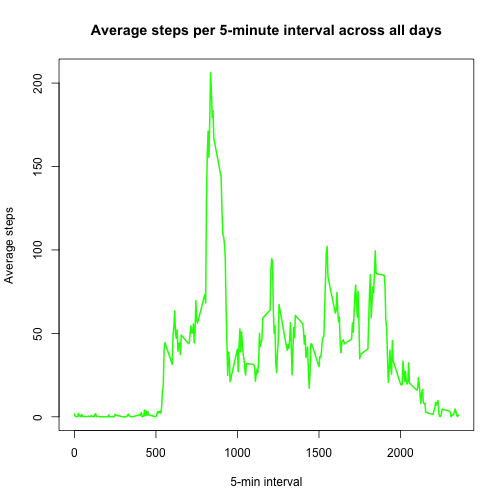

```r
plot(intv$interval, intv$steps, type = "l", xlab = "5-min interval", ylab = "Average steps", main = "Average steps per 5-minute interval across all days", col = "green", lwd = 2)
```

Which 5-minute interval, on average across all the days in the dataset, contains the maximum number of steps?

```r
which.max(intv$steps)
```

```
## [1] 104
```

```r
intv[104, ]
```

```
##     interval    steps
## 104      835 206.1698
```

### 3) Imputing missing values

Calculate and report the total number of missing values in the dataset (i.e. the total number of rows with 𝙽𝙰s)

```r
sum(is.na(act$steps))
```

```
## [1] 2304
```

- Find the percentage of missing values

```r
sum(is.na(act$steps)) / length(act$steps)
```

```
## [1] 0.1311475
```

- That means, 13.1% of the data are missing values.

Devise a strategy for filling in all of the missing values in the dataset. The strategy does not need to be sophisticated. For example, you could use the mean/median for that day, or the mean for that 5-minute interval, etc.

- Create parallel dataset

```r
act2 <- read.csv("activity.csv", header = TRUE)
```

- I will consider the missing values to be the mean of 5-minute intervals. I'll use “tapply” instead of “aggregate” because “tapply” creates an array instead of a data.frame, which is what we need to impute values.

```r
NAs <- is.na(act2$steps)
avg_interval <- tapply(act2$steps, act2$interval, mean, na.rm = TRUE)
act2$steps[NAs] <- avg_interval[as.character(act2$interval[NAs])]
```

Create a new dataset that is equal to the original dataset but with the missing data filled in.

```r
head(act2)
```

```
##       steps       date interval
## 1 1.7169811 2012-10-01        0
## 2 0.3396226 2012-10-01        5
## 3 0.1320755 2012-10-01       10
## 4 0.1509434 2012-10-01       15
## 5 0.0754717 2012-10-01       20
## 6 2.0943396 2012-10-01       25
```

```r
summary(act2)
```

```
##      steps                date          interval
##  Min.   :  0.00   2012-10-01:  288   Min.   :   0.0
##  1st Qu.:  0.00   2012-10-02:  288   1st Qu.: 588.8
##  Median :  0.00   2012-10-03:  288   Median :1177.5
##  Mean   : 37.38   2012-10-04:  288   Mean   :1177.5
##  3rd Qu.: 27.00   2012-10-05:  288   3rd Qu.:1766.2
##  Max.   :806.00   2012-10-06:  288   Max.   :2355.0
##                   (Other)   :15840
```

Make a histogram of the total number of steps taken each day and Calculate and report the mean and median total number of steps taken per day. Do these values differ from the estimates from the first part of the assignment? What is the impact of imputing missing data on the estimates of the total daily number of steps?

- Find the total number of steps per day

```r
stepdf2 <- aggregate(act2$steps, list(date=act2$date), sum)
names(stepdf2) <- c("date", "sum")
stepdf2
```

```
##          date      sum
## 1  2012-10-01 10766.19
## 2  2012-10-02   126.00
## 3  2012-10-03 11352.00
## 4  2012-10-04 12116.00
## 5  2012-10-05 13294.00
## 6  2012-10-06 15420.00
## 7  2012-10-07 11015.00
## 8  2012-10-08 10766.19
## 9  2012-10-09 12811.00
## 10 2012-10-10  9900.00
## 11 2012-10-11 10304.00
## 12 2012-10-12 17382.00
## 13 2012-10-13 12426.00
## 14 2012-10-14 15098.00
```

[output cut: 47 more lines]

- Make a histogram

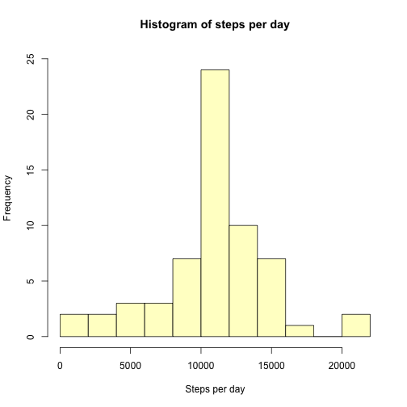

```r
hist(stepdf2$sum, 10, main = "Histogram of steps per day", xlab = "Steps per day", ylim = c(0,25), col = "#FFFFCC")
```

The impact of distributing missing values is that the histogram looks more like a normal distribution now.

- Find the mean number of steps per day

```r
amean2 <- aggregate(act2$steps, list(date=act2$date), mean)
names(amean2) <- c("date", "mean")
amean2
```

```
##          date       mean
## 1  2012-10-01 37.3825996
## 2  2012-10-02  0.4375000
## 3  2012-10-03 39.4166667
## 4  2012-10-04 42.0694444
## 5  2012-10-05 46.1597222
## 6  2012-10-06 53.5416667
## 7  2012-10-07 38.2465278
## 8  2012-10-08 37.3825996
## 9  2012-10-09 44.4826389
## 10 2012-10-10 34.3750000
## 11 2012-10-11 35.7777778
## 12 2012-10-12 60.3541667
## 13 2012-10-13 43.1458333
## 14 2012-10-14 52.4236111
```

[output cut: 47 more lines]

- Total average:

```r
mean2 <- mean(amean2$mean)
mean2
```

```
## [1] 37.3826
```

- Find the median number of steps per day

```r
amedian2 <- aggregate(act2$steps, list(date=act2$date), median)
names(amedian2) <- c("date", "median")
amedian2
```

```
##          date   median
## 1  2012-10-01 34.11321
## 2  2012-10-02  0.00000
## 3  2012-10-03  0.00000
## 4  2012-10-04  0.00000
## 5  2012-10-05  0.00000
## 6  2012-10-06  0.00000
## 7  2012-10-07  0.00000
## 8  2012-10-08 34.11321
## 9  2012-10-09  0.00000
## 10 2012-10-10  0.00000
## 11 2012-10-11  0.00000
## 12 2012-10-12  0.00000
## 13 2012-10-13  0.00000
## 14 2012-10-14  0.00000
```

[output cut: 47 more lines]

- Total median:

```r
median2 <- median(amedian2$median)
```

The impact on the total mean is:

```r
mean1 - mean2
```

```
## [1] 0
```

The impact on the total median is:

```r
median1 - median2
```

```
## [1] 0
```

### 4) Are there differences in activity patterns between weekdays and weekends?

Create a new factor variable in the dataset with two levels – “weekday” and “weekend” indicating whether a given date is a weekday or weekend day.

- Convert date column to 'date' format

```r
act2$date <- as.Date(as.character(act2$date))
```

- Sort dates by weekdays and weekend and create new level

```r
act2$date <- as.Date(as.character(act2$date))
act2$days <- weekdays(act2$date, abbreviate = TRUE)
act2$days <- gsub("Sat|Sun", "weekend", act2$days)
act2$days <- gsub("Mon|Tue|Wed|Thu|Fri", "weekday", act2$days)
unique(act2$days)
```

```
## [1] "weekday" "weekend"
```

Make a panel plot containing a time series plot (i.e. 𝚝𝚢𝚙𝚎 = “𝚕”) of the 5-minute interval (x-axis) and the average number of steps taken, averaged across all weekday days or weekend days (y-axis). See the README file in the GitHub repository to see an example of what this plot should look like using simulated data.

```r
wday <- act2[ which(act2$days == "weekday"), ]
wdayint <- aggregate(wday$steps, list(int=wday$interval), mean)
```

```r
wend <- act2[ which(act2$days == "weekend"), ]
wendint <- aggregate(wend$steps, list(int=wend$interval), mean)
```

- Create tidy dataset

```r
tidyg <- data.frame(int=wdayint$int, Weekend=wendint$x, Weekday=wdayint$x)
library(reshape2)
tidyg <- melt(tidyg, id="int")
names(tidyg) <- c("int", "day", "mean")
```

- Create graph

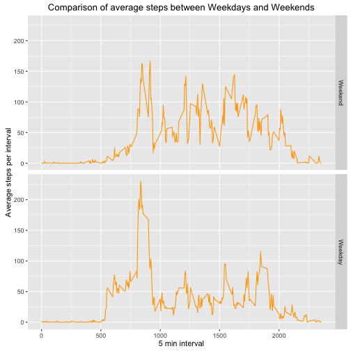

```r
library(ggplot2)
p <- ggplot(tidyg, aes(x=int, y=mean)) + geom_line(color = "orange") + facet_grid(day ~ .)
p <- p + labs(x="5 min interval", y="Average steps per interval")
p + ggtitle("Comparison of average steps between Weekdays and Weekends")
```

Yes, there are differences between the two graphs. For weekdays, one can see that a person in average start taking steps earlier in the day and then there is a peak (we can assume that the person is going to work or school). Then, the average steps count is steeply reduced until end of afternoon, when there's a peak again. We can assume that most people work or study sitting down, and then take steps to go back home.